# Germany district MPs

Holger Doering — doering@uni-bremen.de

16 June 2021, 08:04

```r
library(estimatr)   # robust standard errors
library(patchwork)  # arrrange plots
library(sf)         # plot maps and gespatial tools
library(tidyverse)

ggplot2::theme_set(theme_void())

crs_deu <- "+proj=lcc +lat_1=48 +lat_2=53 +lat_0=51 +lon_0=10"  # LCC Germany parameters
```

# Source

The Federal Returning Officer ("Der Bundeswahlleiter): Bundestag election 2017

- [results](https://www.bundeswahlleiter.de/en/bundestagswahlen/2017/ergebnisse.html) constituencies
  - © The Federal Returning Officer, Wiesbaden 2017
- [geometric data](https://www.bundeswahlleiter.de/en/bundestagswahlen/2017/wahlkreiseinteilung/downloads.html) of constituencies
  - © Der Bundeswahlleiter, Statistisches Bundesamt, Wiesbaden 2016, Wahlkreiskarte für die Wahl zum 19. Deutschen Bundestag, Basis of the geological information © Geobasis-DE / BKG (2016)

```r
bw_raw <- read_csv("data/btw-2017-party.csv")

bw_tier1 <- bw_raw %>% filter(level == "district", votes_type == "Erststimmen")
bw_tier2 <- bw_raw %>% filter(level == "district", votes_type == "Zweitstimmen")

mp_raw <-
  read_delim("data/btw17_gewaehlte_utf8.csv", delim = ";", skip = 6) %>%
  janitor::clean_names()

mp <-
  mp_raw %>%
  filter(gewahlt_stimmenart == "E") %>%
  mutate(
    sex = str_replace(geschlecht, "w", "f"),
    region = if_else(gewahlt_land %in% c("BB", "MV", "SN", "ST", "TH"), "east", "west"),  # "BE"
    region = factor(region) %>% fct_relevel("west")
    ) %>%
  select(
    state = gewahlt_land,
    region,
    district_name = gewahlt_wahlkreis_bez,
    wkr_nr = gewahlt_wahlkreis_nr,
    party = partei_kurz_bez,
    sex
    )

wk_shp <-
  read_rds("data/btw17-districts-geometry.rds") %>%
      left_join(mp %>% distinct(wkr_nr, region))
wk_ctr <- read_rds("data/btw17-districts-centroid.rds")
```

# Votes

## Results

party votes share federal level

- candidate tier (first tier) — “Erststimmen”
- party tier (second tier) — (“Zweitstimmen”)

```r
bw_raw %>%
  filter(level == "federal") %>%
  mutate(party = if_else(party %in% c("CDU", "CSU"), "CDU/CSU", party)) %>%
  group_by(votes_type, party) %>%
  summarise(share = sum(share) %>% round(1)) %>%
  pivot_wider(names_from = votes_type, values_from = share)
```

| party | Erststimmen | Zweitstimmen |
| --- | --- | --- |
| AfD | 11.5 | 12.6 |
| CDU/CSU | 37.3 | 32.9 |
| DIE LINKE | 8.6 | 9.2 |
| FDP | 7.0 | 10.8 |
| GRÜNE | 8.0 | 8.9 |
| SPD | 24.6 | 20.5 |

## Party votes

```r
pl_dt <-
  wk_shp %>%
  select(wkr_nr, geometry) %>%
  right_join(bw_tier2) %>%
  mutate(party = if_else(party %in% c("CDU", "CSU"), "CDU/CSU", party)) %>%
  group_by(party) %>%
  mutate(share_diff = share - mean(share))
```

**party tier** (“Zweitstimmen”) vote share electoral districts

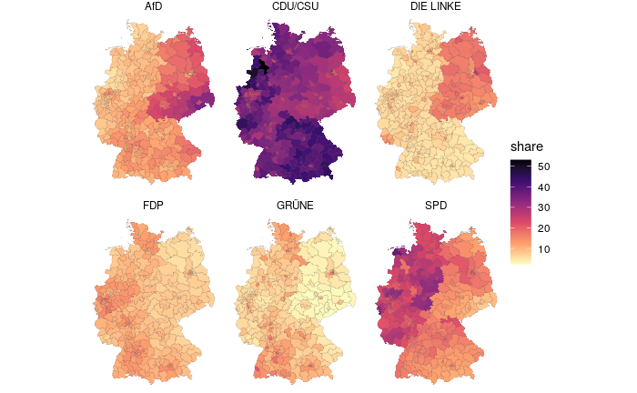

```r
pl1 <-
  ggplot() +
  geom_sf(data = pl_dt, aes(fill = share), lwd = 0.05) +
  scale_fill_viridis_c(option = "magma", direction = -1) +
  coord_sf(crs = crs_deu) +
  facet_wrap(vars(party))
pl1
```

**difference (+/-)** of votes share party **district** from **national average** votes share party

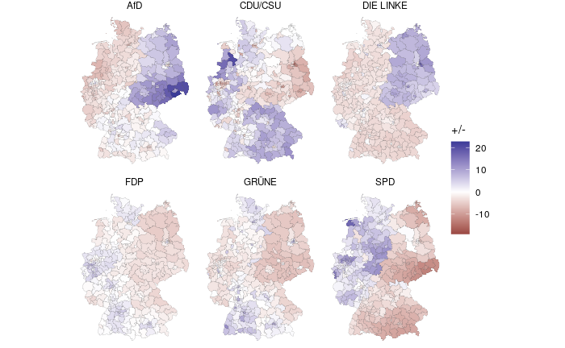

```r
pl2 <-
  ggplot() +
  geom_sf(data = pl_dt, aes(fill = share_diff), lwd = 0.05) +
  scale_fill_gradient2(name = "+/-") +
  coord_sf(crs = crs_deu) +
  facet_wrap(vars(party))
pl2

ggsave("z-btw17-vote-share.png", pl1 / pl2, width = 5, height = 7)
```

## Candidate votes

**candidate tier** (“Erststimmen”) vote share by party

- A — plurality vote **winning party**
- B — sum of candidate votes share **difference** by **ideology**
  - right — AfD, CDU, CSU, FDP
  - left — DIE LINKE, GRÜNE, SPD
- I – votes share **plurality winner**
- II – votes share **difference top 2** results

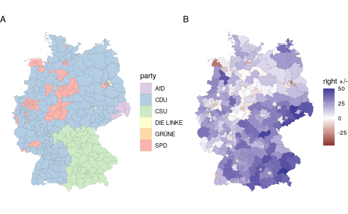

```r
party_scale <- c("#decbe4", "#b3cde3", "#ccebc5", "#ffffcc", "#fed9a6", "#fbb4ae")

ideo_share <-
  bw_tier1 %>%
  group_by(wkr_nr, ideology) %>%
  summarise(share = sum(share)) %>%
  pivot_wider(names_from = ideology, values_from = share) %>%
  mutate(rl_diff = right - left)

pl_dt <-
  wk_shp %>%
  select(wkr_nr, geometry) %>%
  inner_join(ideo_share) %>%
  inner_join(mp %>% select(wkr_nr, party))

pl1 <-
  ggplot() +
  geom_sf(data = pl_dt, aes(fill = party), lwd = 0.05) +
  coord_sf(crs = crs_deu) +
  scale_fill_manual(values = party_scale)
# print(pl1)

pl2 <-
  ggplot() +
  geom_sf(data = pl_dt, aes(fill = rl_diff), lwd = 0.05) +
  coord_sf(crs = crs_deu) +
  scale_fill_gradient2(name = "right +/-")
# print(pl2)

pl1 + pl2 + plot_annotation(tag_levels = "A")
```

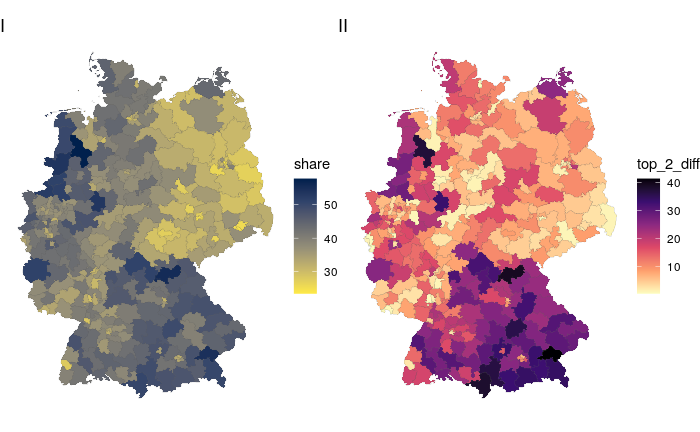

```r
diff_1_2 <-
  bw_tier1 %>%
  arrange(wkr_nr, desc(share)) %>%
  group_by(wkr_nr) %>%
  filter(row_number() %in% c(1, 2)) %>%
  summarise(
    top_2_diff = max(share) - min(share),
    share = max(share)
  )

pl_dt <-
  wk_shp %>%
  select(wkr_nr, geometry) %>%
  inner_join(diff_1_2)

pl1 <-
  ggplot() +
  geom_sf(data = pl_dt, aes(fill = share), lwd = 0.05) +
  coord_sf(crs = crs_deu) +
  scale_fill_viridis_c(option = "cividis", direction = -1)
# print(pl1)

pl2 <-
  ggplot() +
  geom_sf(data = pl_dt, aes(fill = top_2_diff), lwd = 0.05) +
  coord_sf(crs = crs_deu) +
  scale_fill_viridis_c(option = "magma", direction = -1)
# print(pl2)

pl1 + pl2 + plot_annotation(tag_levels = "I")
```

# Female MPs

## Maps

plurality winner candidate (first) tier vote by party and sex

### Germany

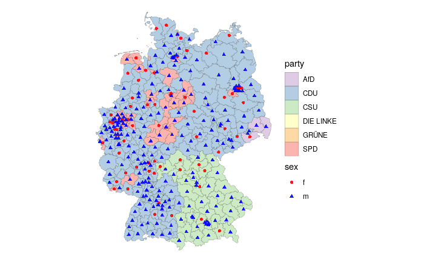

```r
scale_sex <- c("red", "blue")

pl_dt_shp <- wk_shp %>% left_join(mp)
pl_dt_ctr <- wk_ctr %>% left_join(mp)

ggplot() +
  geom_sf(data = pl_dt_shp, aes(fill = party), lwd = 0.1) +
  # scale_fill_brewer(type = "qual", palette = 4) +
  scale_fill_manual(values = party_scale) +
  geom_sf(data = pl_dt_ctr, aes(shape = sex, colour = sex), alpha = 0.9) +
  coord_sf(crs = crs_deu) +
  scale_colour_manual(values = scale_sex)
```

### NRW and Berlin

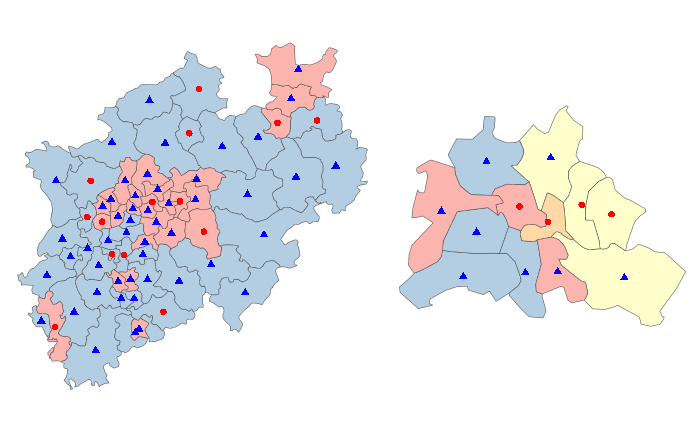

```r
plot_state <- function(state_select, party_scale_select) {
  pl_dt_shp_re <- pl_dt_shp %>% filter(state == state_select)
  pl_dt_ctr_re <- pl_dt_ctr %>% filter(state == state_select)

  ggplot() +
    geom_sf(data = pl_dt_shp_re, aes(fill = party), lwd = 0.2) +
    scale_fill_manual(values = party_scale_select) +
    geom_sf(data = pl_dt_ctr_re, aes(shape = sex, colour = sex), size = 2) +
    scale_colour_manual(values = scale_sex) +
    guides(colour = FALSE, fill = FALSE, shape = FALSE)
}

pl1 <- plot_state("NW", party_scale[c(2, 6)])
pl2 <- plot_state("BE", party_scale[c(2, 4, 5, 6)])
# plot_state("HH", party_scale[c(2, 6)])
pl1 + pl2 + plot_layout(widths = c(55, 45))
```

## Descriptives

number (n) of districts won by party and sex (f – female, m – male)

### Party

```r
count_party <-
  mp %>%
  count(party, sex) %>%
  pivot_wider(names_from = sex, values_from = n) %>%
  replace(is.na(.), 0) %>%
  mutate(share_f = round(100 * f / (m + f)))

count_party %>% arrange(share_f)
```

| party | f | m | share_f |
| --- | --- | --- | --- |
| CSU | 8 | 38 | 17 |
| CDU | 36 | 149 | 19 |
| SPD | 16 | 43 | 27 |
| AfD | 1 | 2 | 33 |
| DIE LINKE | 2 | 3 | 40 |
| GRÜNE | 1 | 0 | 100 |

```r
mp %>%
  count(party) %>%
  mutate(share = round(100 * n / sum(n))) %>%
  arrange(desc(share))
```

| party | n | share |
| --- | --- | --- |
| CDU | 185 | 62 |
| SPD | 59 | 20 |
| CSU | 46 | 15 |
| DIE LINKE | 5 | 2 |
| AfD | 3 | 1 |
| GRÜNE | 1 | 0 |

### States

```r
count_state <-
  mp %>%
  left_join(wk_shp %>% select(wkr_nr, state_name = land_name)) %>%
  count(state_name, sex) %>%
  pivot_wider(names_from = sex, values_from = n) %>%
  mutate(share_f = round(100 * f / (m + f)))

count_state %>% arrange(share_f)
```

| state_name | f | m | share_f |
| --- | --- | --- | --- |
| Baden-Württemberg | 3 | 35 | 8 |
| Sachsen-Anhalt | 1 | 8 | 11 |
| Thüringen | 1 | 7 | 12 |
| Bayern | 8 | 38 | 17 |
| Hamburg | 1 | 5 | 17 |
| Nordrhein-Westfalen | 14 | 50 | 22 |
| Hessen | 5 | 17 | 23 |
| Niedersachsen | 7 | 23 | 23 |
| Sachsen | 4 | 12 | 25 |
| Rheinland-Pfalz | 4 | 11 | 27 |

[output cut: 6 more lines]

# Models

- area_km2 — size of district as square length (root of area)
- coord_y — north/south position (latitude)
- left_share — share of left parties (SPD, Linke, Grüne)
- region – western or eastern (former GDR) state

```r
library(broom)
library(ggeffects)

mo_dt <-
  pl_dt_shp %>%
  left_join(ideo_share) %>%
  mutate(
    female = if_else(sex == "f", 1, 0),
    left_share = left
    )
```

## Female first-tier winners

Logit model to predict female winners of candidate (first) tier vote

```r
mo_glm <- glm(female ~ area_km2 + coord_y + left_share, data = mo_dt, family = "binomial")

tidy(mo_glm) %>% mutate(across(where(is.numeric), round, 2))
```

| term | estimate | std.error | statistic | p.value |
| --- | --- | --- | --- | --- |
| (Intercept) | -11.05 | 4.78 | -2.31 | 0.02 |
| area_km2 | 0.00 | 0.01 | -0.38 | 0.70 |
| coord_y | 0.18 | 0.11 | 1.71 | 0.09 |
| left_share | 0.01 | 0.03 | 0.56 | 0.57 |

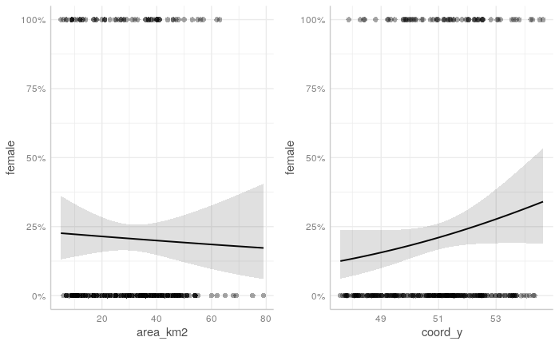

```r
pl1 <- ggpredict(mo_glm, terms = "area_km2 [all]") %>% plot(add.data = TRUE, show.title = FALSE)
pl2 <- ggpredict(mo_glm, terms = "coord_y [all]") %>% plot(add.data = TRUE, show.title = FALSE)
pl1 + pl2
```

## Left vote-share

Linear model of left parties (SPD, Linke, Grüne) vote share

```r
mo_lm <- lm_robust(left_share ~ area_km2*region + coord_y*region, data = mo_dt)

tidy(mo_lm) %>% mutate(across(where(is.numeric), round, 2))
```

| term | estimate | std.error | statistic | p.value | conf.low | conf.high | df | outcome |
| --- | --- | --- | --- | --- | --- | --- | --- | --- |
| (Intercept) | -68.47 | 10.15 | -6.75 | 0.00 | -88.45 | -48.50 | 293 | left_share |
| area_km2 | -0.34 | 0.03 | -13.28 | 0.00 | -0.39 | -0.29 | 293 | left_share |
| regioneast | -117.28 | 60.10 | -1.95 | 0.05 | -235.56 | 1.01 | 293 | left_share |
| coord_y | 2.37 | 0.20 | 12.01 | 0.00 | 1.98 | 2.75 | 293 | left_share |
| area_km2:regioneast | 0.14 | 0.06 | 2.47 | 0.01 | 0.03 | 0.25 | 293 | left_share |
| regioneast:coord_y | 2.11 | 1.18 | 1.78 | 0.08 | -0.22 | 4.44 | 293 | left_share |

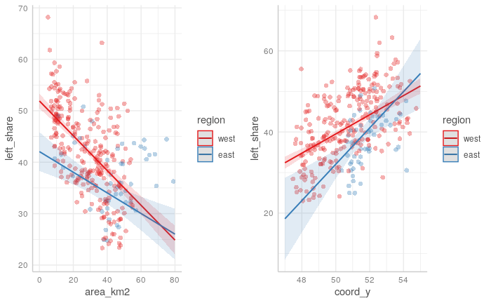

```r
pl1 <- ggpredict(mo_lm, c("area_km2", "region")) %>% plot(add.data = TRUE, show.title = FALSE)
pl2 <- ggpredict(mo_lm, terms = c("coord_y", "region")) %>% plot(add.data = TRUE, show.title = FALSE)
pl1 + pl2
```

## Party vote-share

Linear model of party vote share

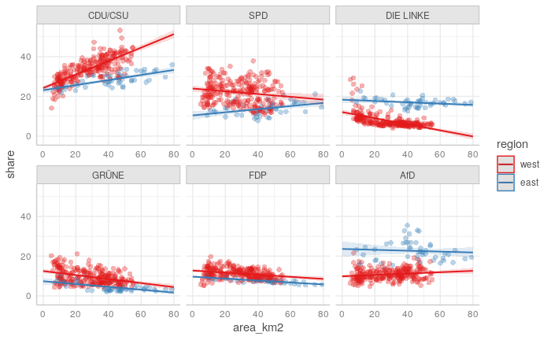

```r
mo_dt2 <-
  bw_tier2 %>%
  mutate(party = if_else(party %in% c("CDU", "CSU"), "CDU/CSU", party)) %>%
  # mutate(party = fct_relevel(party, "CDU")) %>%
  left_join(wk_shp)

mo_lm2 <- lm_robust(share ~ party*area_km2*region, data = mo_dt2)

# tidy(mo_lm2) %>% mutate(across(where(is.numeric), round, 2))

ggpredict(mo_lm2, terms = c( "area_km2", "region", "party")) %>%
  plot(add.data = TRUE, show.title = FALSE)
```